# Antibody Responder Prediction Using Deep Learning Models

This notebook aims to benchmark **longitudinal prediction models** for immune response using time-series gene expression data derived from human viral vaccination studies. We implement and evaluate several deep learning models:

- **Logistic regression with PCA-reduced features and timepoint as predictor**
- **SimpleRNN**
- **GRU**
- **LSTM**
- **Transformer**

These models are tested across three different **batch correction methods**:

- Quantile Normalization (QN)
- Regression-based residuals
- ComBat

All models are assessed using **stratified 5-fold cross-validation**, and evaluated with:

- Accuracy
- F1-score
- AUC (Area Under the ROC Curve)

## Section 1: Data Loading and Preprocessing

We begin by loading the preprocessed gene expression matrices and associated sample metadata. Key preprocessing steps include:

- **By customized criteria load data from HR-VILAGE-3K3M Repo**
- **Log2 transformation** of RNA-seq samples
- **Quantile normalization** across samples
- **Filtering genes** with low mean and variance (bottom 25%)
- Aligning metadata (`combined_ID`, `timepoint_numeric`, and `responder2`) to expression data

This ensures consistency across all input formats for both deep learning and traditional baseline models.

```python
import os
os.environ["CUDA_VISIBLE_DEVICES"] = "-1"
from huggingface_hub import login
from datasets import load_dataset
import pandas as pd

# Define variables
repo_id = "xuejun72/HR-VILAGE-3K3M"  # Your dataset repo on Hugging Face

study_meta = load_dataset(repo_id, data_files = "study_meta.csv")["train"].to_pandas()
```

**Sample Inclusion Criteria:** We curated the dataset to include only influenza or influenza/pneumococcal vaccine studies with recorded antibody responses. Samples were limited to those collected before day 28 post-vaccination to capture early immune responses. Subjects receiving placebo or control vaccines (e.g., Saline, Pneumovax) were excluded. We binarized the antibody response into *High-responder* vs. *Low-responder* (combining Moderate and Non-responders) and removed studies with severely unbalanced class distributions. A unique `combined_ID` was generated for each subject to enable longitudinal modeling.

```python
# === Step 0: Select study_IDs based on inclusion criteria ===

# === Step 1: Load and subset metadata to selected study_IDs ===
split_filter = {"study_type": ["vaccine","mixed exposure"], "platform": [], "tissue": [], "pathogen": ["influenza","influenza/pneumococcal"],"antibody": ["yes"]}
meta_df = load_dataset(repo_id, name = "meta", trust_remote_code=True, split_filter=split_filter, revision="script")

for _, value in meta_df.items():
    meta_df = value.to_pandas().set_index("row_name")

filtered_meta_df = meta_df

# === Step 2: Remove rows without a recorded responder status ===
filtered_meta_df = filtered_meta_df.dropna(subset=['responder']).copy()

# === Step 3: Collapse responder into binary responder2:
# 'High-responder' vs. 'Low-responder' (includes Moderate + Non)
filtered_meta_df['responder2'] = filtered_meta_df['responder'].replace({
    'High-responder': 'High-responder',
    'Moderate-responder': 'Low-responder',
    'Non-responder': 'Low-responder'
})

# === Step 4: Print responder2 counts per study before further exclusions ===
print("\n✅ Responder2 distribution by study (before exclusions):")
initial_summary = pd.crosstab(filtered_meta_df["study_ID"], filtered_meta_df["responder2"])
print(initial_summary)

# === Step 5: Exclude studies with severely unbalanced or problematic class distributions ===
excluded_studies = ['GSE29615', 'GSE45735', 'GSE74815']
filtered_meta = filtered_meta_df[~filtered_meta_df["study_ID"].isin(excluded_studies)].copy()

# === Step 6: Remove subjects that received control/placebo vaccines (e.g., Pneumovax, Saline) ===
filtered_meta = filtered_meta[~filtered_meta['vaccine'].isin(['Pneumovax', 'Saline'])].copy()

# === Step 7: Convert 'timepoint' column to numeric to allow numeric comparisons (e.g., "0", "7", etc.) ===
filtered_meta['timepoint_numeric'] = pd.to_numeric(filtered_meta['timepoint'], errors='coerce')

# === Step 8: Create a unique subject ID by concatenating study_ID and individual ID ===
filtered_meta['combined_ID'] = filtered_meta['study_ID'].astype(str) + "_" + filtered_meta['ID'].astype(str)

# === Step 9: Restrict to timepoints that occur before day 28 (early immune response period) ===
filtered_meta = filtered_meta[filtered_meta['timepoint_numeric'] < 28].copy()

# === Step 10: Print final summary of responder2 counts per study after all filters ===
print("\n✅ Responder2 distribution by study (after filtering):")
final_summary = pd.crosstab(filtered_meta["study_ID"], filtered_meta["responder2"])
print(final_summary)
```

```
Generating vaccine.mixed_exposure_influenza.influenza_pneumococcal_yes split: 836 examples [00:00, 7776.51 examples/s]
```

```
Loading GSE194378...

Loading GSE74811...

Loading GSE74813...

Loading GSE74815...

Loading GSE74816...

Loading GSE48023...

Loading GSE48018...
```

```
Generating vaccine.mixed_exposure_influenza.influenza_pneumococcal_yes split: 2990 examples [00:00, 6982.14 examples/s]
```

```
Loading GSE41080...

Loading GSE59743...

Loading GSE59654...

Loading GSE101709...

Loading GSE59635...

Loading GSE101710...

Loading GSE47353...

Loading SDY311...

Loading SDY112...

Loading SDY315...

Loading GSE207750...
```

```
Generating vaccine.mixed_exposure_influenza.influenza_pneumococcal_yes split: 4158 examples [00:00, 6792.73 examples/s]
```

```
Loading GSE29614...

Loading GSE29615...

Loading GSE29617...

Loading GSE48762...

Loading GSE45735...

✅ Responder2 distribution by study (before exclusions):
responder2  High-responder  Low-responder
study_ID
GSE101709               42             56
GSE101710               59             20
GSE194378              228            154
GSE207750               78            193
GSE29614                21              6
GSE29615                 3             80
GSE29617                59             21
GSE41080                56             26
GSE45735                54              0
GSE47353               229             55
GSE48018               412             14
GSE48023               386             31
GSE48762               191            178
GSE59635                42             30
GSE59654                56            100
GSE59743                56             64
GSE74811                48             35
GSE74813               233             48
GSE74815                66              9
GSE74816                82             95
SDY112                  59             30
SDY311                  48             22
SDY315                  29             40

✅ Responder2 distribution by study (after filtering):
responder2  High-responder  Low-responder
study_ID
GSE101709               31             42
GSE101710               45             16
GSE194378              183            123
GSE207750               78            193
GSE29614                21              6
GSE29617                59             21
GSE41080                56             26
GSE47353               184             43
GSE48018               412             14
GSE48023               386             31
GSE48762               106             54
GSE59635                32             23
GSE59654                43             75
GSE59743                42             48
GSE74811                48             35
GSE74813               233             48
GSE74816                82             95
SDY112                  59             30
SDY311                  46             21
SDY315                  29             40
```

```python
import time


# Start timer
start_time = time.time()

gene_expr_df = load_dataset(repo_id, name = "bulk_gene_expr", trust_remote_code=True, split_filter=split_filter, revision="script")
gene_names = gene_expr_df["gene_expr_colnames"][0]["gene_names"]

all_row_names = []
all_matrix = []
for batch in next(iter(gene_expr_df.items()))[1]:
    all_row_names.extend(batch["row_names"])
    all_matrix.extend(batch["matrix"])
gene_expr_df = pd.DataFrame(all_matrix, index=all_row_names, columns=gene_names)
gene_expr_df


# End timer
end_time = time.time()
elapsed_minutes = (end_time - start_time) / 60

print(f"✅ gene_expr loaded with shape: {gene_expr_df.shape}")
print(f"⏱️ Time taken to load gene_expr: {elapsed_minutes:.2f} minutes")

# Use the index of filtered_meta directly
matching_ids = filtered_meta.index

# Filter gene_expr_df to keep only matching rownames (GSM IDs)
filtered_gene_expr_df = gene_expr_df.loc[gene_expr_df.index.intersection(matching_ids)]
# Drop columns (genes) that contain any NaNs
filtered_gene_expr_df = filtered_gene_expr_df.dropna(axis=1)

print(f"✅ Filtered gene_expr shape: {filtered_gene_expr_df.shape}")
```

```
✅ gene_expr loaded with shape: (4158, 41667)
⏱️ Time taken to load gene_expr: 1.34 minutes
✅ Filtered gene_expr shape: (3159, 14554)
```

## Section 2: Batch Effect Correction

To address technical variability across studies, we applied three normalization strategies. First, RNA-seq samples were log-transformed using `log2(x + 1)`, and genes with low mean and variance (bottom 25%) were removed. Then, we applied **Quantile Normalization (QN)**, which aligns the distribution of gene expression values across samples by assigning the average value at each rank, ensuring all samples share the same empirical distribution. Next, we applied **ComBat**, an empirical Bayes method that adjusts for known batch effects (study ID), and **regression-based adjustment**, where study-specific effects were regressed out using `scanpy`’s `regress_out` function. These approaches yielded three harmonized datasets (QN, ComBat, Regression) for downstream modeling and comparison.

```python
import numpy as np
import pandas as pd
import scanpy as sc

# Copy expression and metadata
df = filtered_gene_expr_df.copy()
meta = filtered_meta.copy()

# Apply log2(x + 1) transform to RNA-seq samples
rna_seq_samples = meta[meta["platform"].str.lower() == "rna-seq"].index
df.loc[rna_seq_samples] = np.log2(df.loc[rna_seq_samples] + 1)

# Remove low mean and low variance genes
gene_means = df.mean(axis=0)
gene_vars = df.var(axis=0)

# Determine 25th percentile thresholds
mean_thresh = gene_means.quantile(0.25)
var_thresh = gene_vars.quantile(0.25)

# Filter: keep genes above both thresholds
genes_to_keep = gene_means[(gene_means > mean_thresh) & (gene_vars > var_thresh)].index
df = df[genes_to_keep]

#  R-style quantile normalization (transpose aware)
def quantile_normalize_matrix_rows_are_samples(expr_df):

    df_t = expr_df.T  # Now genes are rows, samples are columns

    # Sort each column (i.e., each sample)
    sorted_mat = np.sort(df_t.values, axis=0)

    # Compute mean of sorted values (average across samples for each rank)
    mean_ranks = np.mean(sorted_mat, axis=1)

    # Get rank indices for each gene in each sample
    ranks = df_t.rank(method="min", axis=0).astype(int) - 1

    # Replace values in original order based on rank
    norm_df_t = df_t.copy()
    for col in df_t.columns:
        norm_df_t[col] = [mean_ranks[r] for r in ranks[col].values]

    return norm_df_t.T  # Return to (samples x genes) shape

# Apply quantile normalization
qn_expr_df = quantile_normalize_matrix_rows_are_samples(df)

print(f"\n✅ Quantile-normalized expression shape: {qn_expr_df.shape}")

adata = sc.AnnData(df)

# Add batch information
adata.obs["batch"] = filtered_meta.loc[adata.obs_names, "study_ID"]

# Apply ComBat
sc.pp.combat(adata, key="batch")

combat_expr_df = pd.DataFrame(adata.X, index=adata.obs_names, columns=adata.var_names)

# Apply ComBat Regress out
sc.pp.regress_out(adata, keys=['batch'])

# Step 5: Convert back to DataFrame
regressed_expr_df = pd.DataFrame(adata.X, index=adata.obs_names, columns=adata.var_names)
print(combat_expr_df.shape)
print(regressed_expr_df.shape)
```

```
✅ Quantile-normalized expression shape: (3159, 7276)
```

```
(3159, 7276)
(3159, 7276)
```

```
✅ Figure saved to tsne_QN.png
```

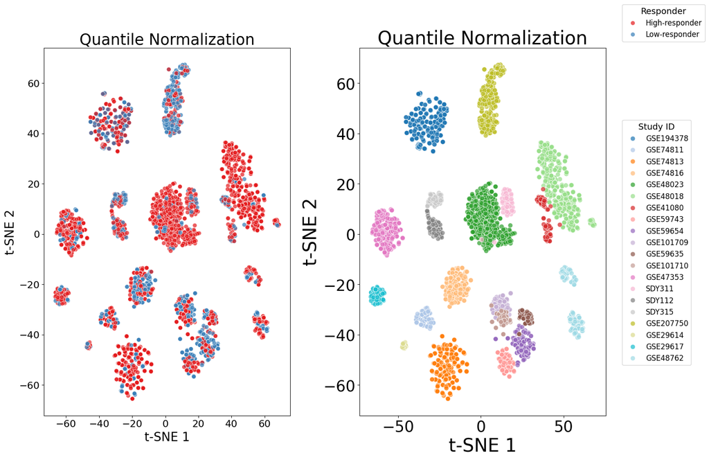

```
✅ Figure saved to tsne_Regressed.png
```

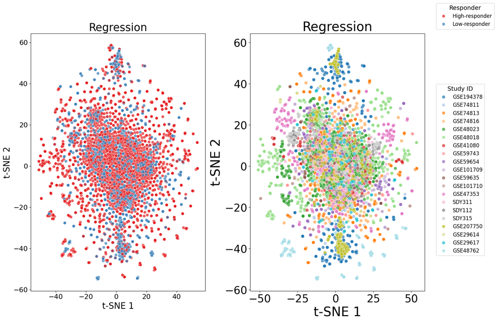

```
✅ Figure saved to tsne_ComBat.png
```

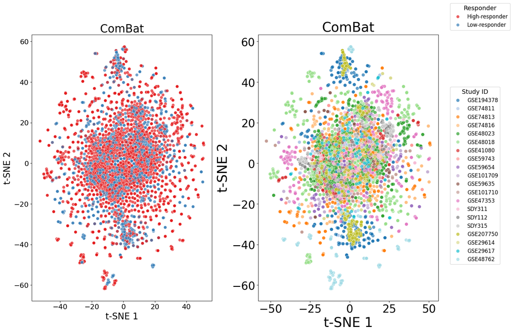

```python
import pandas as pd
import matplotlib.pyplot as plt
import seaborn as sns
from sklearn.manifold import TSNE

# 1. Match metadata to expression data
def match_meta(expr, meta):
    return meta.loc[expr.index]

combat_meta = match_meta(combat_expr_df, filtered_meta)
qn_meta = match_meta(qn_expr_df, filtered_meta)
reg_meta = match_meta(regressed_expr_df, filtered_meta)

# 2. Run t-SNE
def run_tsne(X, random_state=42):
    tsne = TSNE(
        n_components=2,
        random_state=random_state,
        perplexity=30,
        max_iter=1000
    )
    return tsne.fit_transform(X)
combat_meta[['TSNE1', 'TSNE2']] = run_tsne(combat_expr_df)
qn_meta[['TSNE1', 'TSNE2']] = run_tsne(qn_expr_df)
reg_meta[['TSNE1', 'TSNE2']] = run_tsne(regressed_expr_df)

# 3. Define color palettes
palette_outcome = sns.color_palette("Set1", n_colors=2)      # responder2
palette_studyid = sns.color_palette("tab20", n_colors=20)    # study_ID

# 4. Plotting with save option
def plot_tsne_side_by_side(meta, method_name, save_path=None):
    fig, axes = plt.subplots(1, 2, figsize=(14, 10))

    # Plot 1: By responder2
    scatter1 = sns.scatterplot(
        data=meta,
        x='TSNE1', y='TSNE2',
        hue='responder2',
        palette=palette_outcome,
        s=50, alpha=0.7,
        ax=axes[0]
    )
    axes[0].set_title(f"{method_name}", fontsize=25)
    axes[0].set_xlabel("t-SNE 1", fontsize=20)
    axes[0].set_ylabel("t-SNE 2", fontsize=20)
    axes[0].tick_params(labelsize=16)

    # Plot 2: By study_ID
    scatter2 = sns.scatterplot(
        data=meta,
        x='TSNE1', y='TSNE2',
        hue='study_ID',
        palette=palette_studyid,
        s=60, alpha=0.7,
        ax=axes[1]
    )
    axes[1].set_title(f"{method_name}", fontsize=30)
    axes[1].set_xlabel("t-SNE 1", fontsize=30)
    axes[1].set_ylabel("t-SNE 2", fontsize=30)
    axes[1].tick_params(labelsize=25)

    # Remove individual legends
    axes[0].legend_.remove()
    axes[1].legend_.remove()

    # Add shared legends
    handles1, labels1 = scatter1.get_legend_handles_labels()
    handles2, labels2 = scatter2.get_legend_handles_labels()

    fig.legend(handles1, labels1, title='Responder', title_fontsize=14, fontsize=12,
               loc='center left', bbox_to_anchor=(1.01, 1))
    fig.legend(handles2, labels2, title='Study ID', title_fontsize=14, fontsize=12,
               loc='center left', bbox_to_anchor=(1.01, 0.5))

    plt.tight_layout()

    if save_path:
        plt.savefig(save_path, bbox_inches='tight', dpi=300)
        print(f"✅ Figure saved to {save_path}")

    plt.show()

# 5. Generate and save plots
plot_tsne_side_by_side(qn_meta, "Quantile Normalization", save_path="tsne_QN.png")
plot_tsne_side_by_side(reg_meta, "Regression", save_path="tsne_Regressed.png")
plot_tsne_side_by_side(combat_meta, "ComBat", save_path="tsne_ComBat.png")
```

## Section 3: Model Fitting

**Sequence Construction and Padding:** To model temporal gene expression dynamics, we transformed each subject’s longitudinal data into a sequence format by concatenating gene expression vectors with their corresponding timepoints. This was done separately for each normalization method (Quantile Normalization, ComBat, and Regression-adjusted data). The sequences were padded with zeros to match the length of the longest sequence across all subjects, ensuring compatibility with deep learning models that require fixed-length inputs. Each padded dataset was accompanied by binary response labels indicating high or low antibody responders.

```python
import numpy as np
from tqdm import tqdm
import os
import tensorflow as tf
from tensorflow.keras.preprocessing.sequence import pad_sequences

# Function to generate sequence data
def generate_sequence_data(expr_df, combined_meta, subject_label):
    X_seq = []
    y_seq = []
    max_seq_len = 0

    for subject_id, df_sub in tqdm(combined_meta.groupby('combined_ID'), desc="Building sequences"):
        sample_ids = df_sub.sort_values('timepoint_numeric').index  # sorted timepoints

        try:
            timepoints = df_sub.loc[sample_ids, 'timepoint_numeric'].values[:, np.newaxis]  # (T, 1)
            expr = expr_df.loc[sample_ids].values  # (T, G)

            # Combine expression and time
            features = np.concatenate([expr, timepoints], axis=1)  # (T, G+1)
            X_seq.append(features)
            y_seq.append(subject_label.loc[subject_id])
            max_seq_len = max(max_seq_len, features.shape[0])
        except KeyError:
            continue

    return X_seq, y_seq, max_seq_len

# Prepare labels
subject_label = filtered_meta.drop_duplicates('combined_ID').set_index('combined_ID')['responder2']
subject_label = subject_label.map({'High-responder': 1, 'Low-responder': 0})

# Generate sequences for each normalization method
X_seq_qn, y_seq_qn, max_len_qn = generate_sequence_data(qn_expr_df, filtered_meta, subject_label)
X_seq_cb, y_seq_cb, max_len_cb = generate_sequence_data(combat_expr_df, filtered_meta, subject_label)
X_seq_reg, y_seq_reg, max_len_reg = generate_sequence_data(regressed_expr_df, filtered_meta, subject_label)

# Determine global maximum sequence length
max_seq_len_all = max(max_len_qn, max_len_cb, max_len_reg)

# Pad sequences using GPU-enabled TensorFlow
X_padded_qn = pad_sequences(X_seq_qn, maxlen=max_seq_len_all, padding='post', dtype='float32')
X_padded_cb = pad_sequences(X_seq_cb, maxlen=max_seq_len_all, padding='post', dtype='float32')
X_padded_reg = pad_sequences(X_seq_reg, maxlen=max_seq_len_all, padding='post', dtype='float32')

# Convert labels to arrays
y_array_qn = np.array(y_seq_qn)
y_array_cb = np.array(y_seq_cb)
y_array_reg = np.array(y_seq_reg)

# Output shapes
print(f"QN padded shape:        {X_padded_qn.shape}, Labels: {y_array_qn.shape}")
print(f"ComBat padded shape:    {X_padded_cb.shape}, Labels: {y_array_cb.shape}")
print(f"Regressed padded shape: {X_padded_reg.shape}, Labels: {y_array_reg.shape}")
```

[output not shown]

```
QN padded shape:        (1268, 19, 7277), Labels: (1268,)
ComBat padded shape:    (1268, 19, 7277), Labels: (1268,)
Regressed padded shape: (1268, 19, 7277), Labels: (1268,)
```

```python
import numpy as np
import pandas as pd
import gc
from sklearn.decomposition import PCA
from sklearn.model_selection import StratifiedKFold
from sklearn.metrics import accuracy_score, f1_score, roc_auc_score
from sklearn.preprocessing import StandardScaler
import statsmodels.api as sm
import patsy

def run_logistic_pipeline(expr_df, meta_df, method_name, seed_list = [2368, 5272, 9289, 1251, 8825, 355]):
    results = []

    # 1. Ensure matching index
    assert all(expr_df.index == meta_df.index), "Mismatch in sample order"

    # 2. Binary response
    y_array = meta_df["responder2"].map({'High-responder': 1, 'Low-responder': 0}).values
    y_array = pd.to_numeric(y_array, errors="coerce")

    # 3. PCA transformation
    pca = PCA(n_components=100)
    X_pca = pca.fit_transform(expr_df.values)

    # 4. Time feature scaling
    time_feature = meta_df["timepoint_numeric"].astype(float).values.reshape(-1, 1)
    time_feature = StandardScaler().fit_transform(time_feature)

    # 5. Combine features
    X_final = np.concatenate([X_pca, time_feature], axis=1)
    columns = [f"PC{i+1}" for i in range(X_pca.shape[1])] + ["Time"]
    full_df = pd.DataFrame(X_final, columns=columns)
    full_df["y"] = y_array

    # 6. Stratified Cross-validation
    for seed in seed_list:
        print(f"\n=== {method_name} | Seed {seed} ===")
        skf = StratifiedKFold(n_splits=5, shuffle=True, random_state=seed)

        for fold, (train_idx, test_idx) in enumerate(skf.split(X_final, y_array)):
            print(f"  Fold {fold+1}")
            train_df = full_df.iloc[train_idx].copy()
            test_df = full_df.iloc[test_idx].copy()

            try:
                # Design matrices for logistic regression
                formula = "y ~ " + " + ".join(columns)
                y_train, X_train = patsy.dmatrices(formula, data=train_df, return_type='dataframe')
                y_train = y_train.values.ravel()

                # Fit logistic regression
                model = sm.Logit(y_train, X_train)
                result = model.fit(disp=False)

                # Predict on test set
                X_test = patsy.dmatrix(" + ".join(columns), data=test_df, return_type='dataframe')
                y_pred_prob = result.predict(X_test)
                y_pred = (y_pred_prob > 0.5).astype(int)

                acc = accuracy_score(test_df["y"], y_pred)
                f1 = f1_score(test_df["y"], y_pred)
                auc = roc_auc_score(test_df["y"], y_pred_prob)

                results.append({
                    "method": method_name,
                    "seed": seed,
                    "fold": fold + 1,
                    "accuracy": acc,
                    "f1": f1,
                    "auc": auc
                })


            except Exception as e:
                print(f"⚠️ {method_name} failed on seed {seed}, fold {fold+1}: {e}")
                continue

            gc.collect()

    return pd.DataFrame(results)

# === Run Logistic Regression for all normalization methods ===
results_qn  = run_logistic_pipeline(qn_expr_df, filtered_meta, "QN")
results_cb  = run_logistic_pipeline(combat_expr_df, filtered_meta, "ComBat")
results_reg = run_logistic_pipeline(regressed_expr_df, filtered_meta, "Regression")

# === Combine and save results ===
all_results = pd.concat([results_qn, results_cb, results_reg], ignore_index=True)
all_results.to_csv("logistic_regression_results.csv", index=False)

# === Print results ===
print("\n✅ Combined Logistic Regression Results:")
print(all_results.sort_values(["method", "seed", "fold"]))
```

```
=== QN | Seed 2368 ===
  Fold 1
  Fold 2
  Fold 3
  Fold 4
  Fold 5

=== QN | Seed 5272 ===
  Fold 1
  Fold 2
  Fold 3
  Fold 4
  Fold 5

=== QN | Seed 9289 ===
  Fold 1
  Fold 2
  Fold 3
  Fold 4
  Fold 5

=== QN | Seed 1251 ===
  Fold 1
  Fold 2
  Fold 3
  Fold 4
  Fold 5

=== QN | Seed 8825 ===
  Fold 1
  Fold 2
  Fold 3
  Fold 4
  Fold 5

=== QN | Seed 355 ===
  Fold 1
  Fold 2
  Fold 3
  Fold 4
```

[output cut: 86 more lines]

```
✅ Combined Logistic Regression Results:
        method  seed  fold  accuracy        f1       auc
55      ComBat   355     1  0.672468  0.792793  0.568178
56      ComBat   355     2  0.681962  0.801579  0.616722
57      ComBat   355     3  0.655063  0.781124  0.576218
58      ComBat   355     4  0.688291  0.803980  0.580221
59      ComBat   355     5  0.687797  0.804757  0.614051
..         ...   ...   ...       ...       ...       ...
70  Regression  9289     1  0.664557  0.785859  0.604831
71  Regression  9289     2  0.675633  0.797230  0.584608
72  Regression  9289     3  0.696203  0.812133  0.578844
73  Regression  9289     4  0.674051  0.795635  0.603851
74  Regression  9289     5  0.676704  0.797217  0.583779

[90 rows x 6 columns]
```

**RNN, LSTM, and GRU Models:**  
To capture temporal patterns in the longitudinal gene expression data, we implemented three deep learning sequence models: SimpleRNN, LSTM, and GRU. Each model was designed with a single recurrent layer of 64 hidden units followed by a dropout layer (rate = 0.4) to reduce overfitting and a final dense sigmoid output layer for binary classification. We used a masking layer to handle varying sequence lengths and padded all sequences to a unified maximum time length. The models were trained with the Adam optimizer (learning rate = 1e-4), binary cross-entropy loss, and a batch size of 64 for 20 epochs. To ensure robust evaluation, stratified 5-fold cross-validation was repeated across six random seeds. These hyperparameters were chosen based on common practice in biomedical time-series modeling and to maintain consistency across architectures for fair comparison across batch correction methods (Quantile Normalization, ComBat, and Regression).

```python
import os
import tensorflow as tf
import numpy as np
import pandas as pd
import gc
from sklearn.model_selection import StratifiedKFold
from sklearn.metrics import accuracy_score, f1_score, roc_auc_score
from tensorflow.keras import backend as K


# === RNN Model Builder ===
def build_rnn_model(input_dim):
    model = tf.keras.Sequential([
        tf.keras.layers.Masking(mask_value=0.0, input_shape=(None, input_dim)),
        tf.keras.layers.SimpleRNN(64, return_sequences=False),
        tf.keras.layers.Dropout(0.4),
        tf.keras.layers.Dense(1, activation='sigmoid')
    ])
    model.compile(
        optimizer=tf.keras.optimizers.Adam(learning_rate=1e-4),
        loss='binary_crossentropy',
        metrics=['accuracy']
    )
    return model

# === Cross-Validation Runner ===
def run_rnn_cv(X, y, label, out_csv=None):
    seed_list = [2368, 5272, 9289, 1251, 8825, 355]
    all_results = []

    for seed in seed_list:
        print(f"\n=== {label} | Seed {seed} ===")
        kf = StratifiedKFold(n_splits=5, shuffle=True, random_state=seed)

        for fold, (train_idx, test_idx) in enumerate(kf.split(X, y)):
            print(f"  Fold {fold+1}")

            X_train, X_test = X[train_idx], X[test_idx]
            y_train, y_test = y[train_idx], y[test_idx]

            model = build_rnn_model(input_dim=X.shape[2])
            model.fit(
                X_train, y_train,
                epochs=20,
                batch_size=64,
                validation_split=0.2,
                verbose=0
            )

            y_pred_prob = model.predict(X_test, verbose=0).ravel()
            y_pred = (y_pred_prob > 0.5).astype(int)

            acc = accuracy_score(y_test, y_pred)
            f1 = f1_score(y_test, y_pred)
            auc = roc_auc_score(y_test, y_pred_prob)

            print(f"    Accuracy: {acc:.3f} | F1: {f1:.3f} | AUC: {auc:.3f}")

            all_results.append({
                "method": label,
                "seed": seed,
                "fold": fold + 1,
                "accuracy": acc,
                "f1": f1,
                "auc": auc
            })

            del model
            K.clear_session()
            gc.collect()

    results_df = pd.DataFrame(all_results)
    print(f"\n📄 Saving {label} results to: {out_csv if out_csv else 'not saved (out_csv=None)'}")
    print(results_df)
    if out_csv:
        results_df.to_csv(out_csv, index=False)
    return results_df

# === Run and Combine Results ===
results_qn = run_rnn_cv(X_padded_qn, y_array_qn, label="QN")
results_cb = run_rnn_cv(X_padded_cb, y_array_cb, label="ComBat")
results_reg = run_rnn_cv(X_padded_reg, y_array_reg, label="Regression")

combined_results_df = pd.concat([results_qn, results_cb, results_reg], ignore_index=True)
combined_results_df.to_csv("rnn_all_methods.csv", index=False)
print("✅ Combined RNN results saved to rnn_all_methods.csv")
```

```
=== QN | Seed 2368 ===
  Fold 1
```

[output not shown]

```
    Accuracy: 0.602 | F1: 0.752 | AUC: 0.550
  Fold 2
    Accuracy: 0.602 | F1: 0.752 | AUC: 0.497
  Fold 3
    Accuracy: 0.602 | F1: 0.752 | AUC: 0.558
  Fold 4
    Accuracy: 0.605 | F1: 0.754 | AUC: 0.508
  Fold 5
    Accuracy: 0.601 | F1: 0.751 | AUC: 0.500

=== QN | Seed 5272 ===
  Fold 1
    Accuracy: 0.602 | F1: 0.752 | AUC: 0.505
  Fold 2
    Accuracy: 0.602 | F1: 0.752 | AUC: 0.612
  Fold 3
    Accuracy: 0.602 | F1: 0.752 | AUC: 0.679
  Fold 4
    Accuracy: 0.605 | F1: 0.754 | AUC: 0.497
  Fold 5
    Accuracy: 0.601 | F1: 0.751 | AUC: 0.717

=== QN | Seed 9289 ===
  Fold 1
    Accuracy: 0.602 | F1: 0.752 | AUC: 0.500
  Fold 2
    Accuracy: 0.602 | F1: 0.752 | AUC: 0.627
  Fold 3
    Accuracy: 0.602 | F1: 0.752 | AUC: 0.662
  Fold 4
    Accuracy: 0.605 | F1: 0.754 | AUC: 0.503
  Fold 5
    Accuracy: 0.601 | F1: 0.751 | AUC: 0.596

=== QN | Seed 1251 ===
  Fold 1
    Accuracy: 0.602 | F1: 0.752 | AUC: 0.500
  Fold 2
    Accuracy: 0.602 | F1: 0.752 | AUC: 0.657
  Fold 3
```

[output cut: 258 more lines]

```
16  Regression  1251     2  0.555118  0.638978  0.575228
17  Regression  1251     3  0.586614  0.660194  0.619038
18  Regression  1251     4  0.596838  0.668831  0.570327
19  Regression  1251     5  0.592885  0.664495  0.616271
20  Regression  8825     1  0.602362  0.671010  0.616062
21  Regression  8825     2  0.574803  0.649351  0.586941
22  Regression  8825     3  0.519685  0.596026  0.550379
23  Regression  8825     4  0.588933  0.666667  0.652484
24  Regression  8825     5  0.517787  0.606452  0.537520
25  Regression   355     1  0.618110  0.690096  0.647382
26  Regression   355     2  0.539370  0.606061  0.533747
27  Regression   355     3  0.625984  0.705882  0.627386
28  Regression   355     4  0.592885  0.668810  0.640131
29  Regression   355     5  0.529644  0.622222  0.539018
✅ Combined RNN results saved to rnn_all_methods.csv
```

```python
import numpy as np
import pandas as pd
import gc
import tensorflow as tf
from sklearn.model_selection import StratifiedKFold
from sklearn.metrics import accuracy_score, f1_score, roc_auc_score
from tensorflow.keras import backend as K

# 🔧 LSTM Model Builder
def build_lstm_model(input_dim):
    model = tf.keras.Sequential([
        tf.keras.layers.Masking(mask_value=0.0, input_shape=(None, input_dim)),
        tf.keras.layers.LSTM(64, return_sequences=False),
        tf.keras.layers.Dropout(0.4),
        tf.keras.layers.Dense(1, activation='sigmoid')
    ])
    model.compile(optimizer=tf.keras.optimizers.Adam(learning_rate=1e-4),
                  loss='binary_crossentropy',
                  metrics=['accuracy'])
    return model

# 🔁 Cross-Validation Runner
def run_lstm_cv(X_padded, y_array, label="QN"):
    seed_list = [2368, 5272, 9289, 1251, 8825, 355]
    all_results = []

    for seed in seed_list:
        print(f"\n=== LSTM with {label} | Seed {seed} ===")
        skf = StratifiedKFold(n_splits=5, shuffle=True, random_state=seed)

        for fold, (train_idx, test_idx) in enumerate(skf.split(X_padded, y_array)):
            print(f"  Fold {fold+1}")

            X_train, X_test = X_padded[train_idx], X_padded[test_idx]
            y_train, y_test = y_array[train_idx], y_array[test_idx]

            model = build_lstm_model(input_dim=X_padded.shape[2])
            model.fit(
                X_train, y_train,
                epochs=20,
                batch_size=64,
                validation_split=0.2,
                verbose=0
            )

            y_pred_prob = model.predict(X_test, verbose=0).ravel()
            y_pred = (y_pred_prob > 0.5).astype(int)

            acc = accuracy_score(y_test, y_pred)
            f1 = f1_score(y_test, y_pred)
            auc = roc_auc_score(y_test, y_pred_prob)

            print(f"    Accuracy: {acc:.3f} | F1: {f1:.3f} | AUC: {auc:.3f}")

            all_results.append({
                "method": label,
                "seed": seed,
                "fold": fold+1,
                "accuracy": acc,
                "f1": f1,
                "auc": auc
            })

            del model
            K.clear_session()
            gc.collect()

    return pd.DataFrame(all_results)

# 🧪 Run LSTM for all normalization methods
results_qn  = run_lstm_cv(X_padded_qn, y_array_qn, label="QN")
results_cb  = run_lstm_cv(X_padded_cb, y_array_cb, label="ComBat")
results_reg = run_lstm_cv(X_padded_reg, y_array_reg, label="Regression")

# 💾 Save results
combined_results_df = pd.concat([results_qn, results_cb, results_reg], ignore_index=True)
combined_results_df.to_csv("lstm_all_methods.csv", index=False)
print("✅ LSTM results saved to lstm_all_methods.csv")
```

```
=== LSTM with QN | Seed 2368 ===
  Fold 1
    Accuracy: 0.602 | F1: 0.752 | AUC: 0.667
  Fold 2
    Accuracy: 0.602 | F1: 0.752 | AUC: 0.733
  Fold 3
    Accuracy: 0.669 | F1: 0.768 | AUC: 0.666
  Fold 4
    Accuracy: 0.605 | F1: 0.754 | AUC: 0.722
  Fold 5
    Accuracy: 0.601 | F1: 0.751 | AUC: 0.797

=== LSTM with QN | Seed 5272 ===
  Fold 1
    Accuracy: 0.602 | F1: 0.752 | AUC: 0.715
  Fold 2
    Accuracy: 0.602 | F1: 0.752 | AUC: 0.667
  Fold 3
    Accuracy: 0.673 | F1: 0.783 | AUC: 0.712
  Fold 4
    Accuracy: 0.605 | F1: 0.754 | AUC: 0.737
  Fold 5
    Accuracy: 0.601 | F1: 0.751 | AUC: 0.709

=== LSTM with QN | Seed 9289 ===
  Fold 1
    Accuracy: 0.709 | F1: 0.786 | AUC: 0.734
  Fold 2
    Accuracy: 0.602 | F1: 0.752 | AUC: 0.690
  Fold 3
    Accuracy: 0.602 | F1: 0.752 | AUC: 0.722
  Fold 4
    Accuracy: 0.605 | F1: 0.754 | AUC: 0.695
  Fold 5
    Accuracy: 0.601 | F1: 0.751 | AUC: 0.727

=== LSTM with QN | Seed 1251 ===
  Fold 1
    Accuracy: 0.602 | F1: 0.752 | AUC: 0.633
  Fold 2
```

[output cut: 161 more lines]

```
  Fold 5
    Accuracy: 0.696 | F1: 0.762 | AUC: 0.733

=== LSTM with Regression | Seed 355 ===
  Fold 1
    Accuracy: 0.697 | F1: 0.751 | AUC: 0.724
  Fold 2
    Accuracy: 0.677 | F1: 0.753 | AUC: 0.724
  Fold 3
    Accuracy: 0.697 | F1: 0.767 | AUC: 0.723
  Fold 4
    Accuracy: 0.664 | F1: 0.745 | AUC: 0.723
  Fold 5
    Accuracy: 0.625 | F1: 0.718 | AUC: 0.656
✅ LSTM results saved to lstm_all_methods.csv
```

```python
import numpy as np
import pandas as pd
import gc
import tensorflow as tf
from sklearn.model_selection import StratifiedKFold
from sklearn.metrics import accuracy_score, f1_score, roc_auc_score
from tensorflow.keras import backend as K

# 🔧 GRU Model Builder
def build_gru_model(input_dim):
    model = tf.keras.Sequential([
        tf.keras.layers.Masking(mask_value=0.0, input_shape=(None, input_dim)),
        tf.keras.layers.GRU(64, return_sequences=False),
        tf.keras.layers.Dropout(0.4),
        tf.keras.layers.Dense(1, activation='sigmoid')
    ])
    model.compile(optimizer=tf.keras.optimizers.Adam(learning_rate=1e-4),
                  loss='binary_crossentropy',
                  metrics=['accuracy'])
    return model

# 🔁 Cross-Validation Runner
def run_gru_cv(X_padded, y_array, label="QN"):
    seed_list = [2368, 5272, 9289, 1251, 8825, 355]
    all_results = []

    for seed in seed_list:
        print(f"\n=== GRU with {label} | Seed {seed} ===")
        skf = StratifiedKFold(n_splits=5, shuffle=True, random_state=seed)

        for fold, (train_idx, test_idx) in enumerate(skf.split(X_padded, y_array)):
            print(f"  Fold {fold+1}")

            X_train, X_test = X_padded[train_idx], X_padded[test_idx]
            y_train, y_test = y_array[train_idx], y_array[test_idx]

            model = build_gru_model(input_dim=X_padded.shape[2])

            model.fit(
                X_train, y_train,
                epochs=20,
                batch_size=64,
                validation_split=0.2,
                verbose=0
            )

            y_pred_prob = model.predict(X_test, verbose=0).ravel()
            y_pred = (y_pred_prob > 0.5).astype(int)

            acc = accuracy_score(y_test, y_pred)
            f1 = f1_score(y_test, y_pred)
            auc = roc_auc_score(y_test, y_pred_prob)

            print(f"    Accuracy: {acc:.3f} | F1: {f1:.3f} | AUC: {auc:.3f}")

            all_results.append({
                "method": label,
                "seed": seed,
                "fold": fold+1,
                "accuracy": acc,
                "f1": f1,
                "auc": auc
            })

            del model
            K.clear_session()
            gc.collect()

    return pd.DataFrame(all_results)

# 🧪 Run GRU CV for each batch correction method
results_qn  = run_gru_cv(X_padded_qn, y_array_qn, label="QN")
results_cb  = run_gru_cv(X_padded_cb, y_array_cb, label="ComBat")
results_reg = run_gru_cv(X_padded_reg, y_array_reg, label="Regression")

# 💾 Save results
combined_results_df = pd.concat([results_qn, results_cb, results_reg], ignore_index=True)
combined_results_df.to_csv("gru_all_methods.csv", index=False)
print("✅ GRU results saved to gru_all_methods.csv")
```

```
=== GRU with QN | Seed 2368 ===
  Fold 1
    Accuracy: 0.602 | F1: 0.752 | AUC: 0.647
  Fold 2
    Accuracy: 0.602 | F1: 0.752 | AUC: 0.742
  Fold 3
    Accuracy: 0.673 | F1: 0.771 | AUC: 0.634
  Fold 4
    Accuracy: 0.605 | F1: 0.754 | AUC: 0.754
  Fold 5
    Accuracy: 0.711 | F1: 0.787 | AUC: 0.777

=== GRU with QN | Seed 5272 ===
  Fold 1
    Accuracy: 0.602 | F1: 0.752 | AUC: 0.750
  Fold 2
    Accuracy: 0.602 | F1: 0.752 | AUC: 0.628
  Fold 3
    Accuracy: 0.602 | F1: 0.752 | AUC: 0.660
  Fold 4
    Accuracy: 0.605 | F1: 0.754 | AUC: 0.670
  Fold 5
    Accuracy: 0.601 | F1: 0.751 | AUC: 0.702

=== GRU with QN | Seed 9289 ===
  Fold 1
    Accuracy: 0.618 | F1: 0.759 | AUC: 0.756
  Fold 2
    Accuracy: 0.650 | F1: 0.756 | AUC: 0.692
  Fold 3
    Accuracy: 0.602 | F1: 0.752 | AUC: 0.717
  Fold 4
    Accuracy: 0.605 | F1: 0.754 | AUC: 0.678
  Fold 5
    Accuracy: 0.601 | F1: 0.751 | AUC: 0.718

=== GRU with QN | Seed 1251 ===
  Fold 1
    Accuracy: 0.602 | F1: 0.752 | AUC: 0.671
  Fold 2
```

[output cut: 139 more lines]

```
  Fold 5
    Accuracy: 0.648 | F1: 0.721 | AUC: 0.714

=== GRU with Regression | Seed 355 ===
  Fold 1
    Accuracy: 0.677 | F1: 0.734 | AUC: 0.708
  Fold 2
    Accuracy: 0.685 | F1: 0.745 | AUC: 0.697
  Fold 3
    Accuracy: 0.665 | F1: 0.740 | AUC: 0.695
  Fold 4
    Accuracy: 0.648 | F1: 0.726 | AUC: 0.727
  Fold 5
    Accuracy: 0.593 | F1: 0.693 | AUC: 0.598
✅ GRU results saved to gru_all_methods.csv
```

```python
import tensorflow as tf
from tensorflow.keras import layers, models
import numpy as np
from sklearn.model_selection import train_test_split
from sklearn.metrics import classification_report, roc_auc_score
class TimeEmbedding(layers.Layer):
    def __init__(self, embed_dim):
        super().__init__()
        self.mlp = models.Sequential([
            layers.Dense(embed_dim, activation='relu'),
            layers.Dense(embed_dim)
        ])

    def call(self, time_input):
        return self.mlp(time_input)  # shape: (batch, time, embed_dim)

class TransformerBlock(tf.keras.layers.Layer):
    def __init__(self, embed_dim, num_heads, ff_dim, rate=0.1):
        super().__init__()
        self.att = tf.keras.layers.MultiHeadAttention(num_heads=num_heads, key_dim=embed_dim)
        self.ffn = tf.keras.Sequential([
            tf.keras.layers.Dense(ff_dim, activation='relu'),
            tf.keras.layers.Dense(embed_dim)
        ])
        self.layernorm1 = tf.keras.layers.LayerNormalization()
        self.layernorm2 = tf.keras.layers.LayerNormalization()
        self.dropout1 = tf.keras.layers.Dropout(rate)
        self.dropout2 = tf.keras.layers.Dropout(rate)

    def call(self, x, training=None):  # 👈 Add training=None
        attn_output = self.att(x, x, training=training)
        out1 = self.layernorm1(x + self.dropout1(attn_output, training=training))
        ffn_output = self.ffn(out1)
        return self.layernorm2(out1 + self.dropout2(ffn_output, training=training))

def build_transformer(input_dim, embed_dim=64, num_heads=4, ff_dim=128, max_len=100):
    gene_input = layers.Input(shape=(None, input_dim))  # (batch, time, gene_features)
    time_input = layers.Input(shape=(None, 1))           # (batch, time, 1)

    time_embed = TimeEmbedding(embed_dim)(time_input)
    x = layers.Dense(embed_dim)(gene_input)  # project gene features
    x = layers.Add()([x, time_embed])        # add time embedding

    x = TransformerBlock(embed_dim, num_heads, ff_dim)(x)

    x = layers.GlobalAveragePooling1D()(x)
    x = layers.Dropout(0.3)(x)
    x = layers.Dense(64, activation='relu')(x)
    x = layers.Dropout(0.3)(x)
    output = layers.Dense(1, activation='sigmoid')(x)

    model = models.Model(inputs=[gene_input, time_input], outputs=output)
    model.compile(optimizer='adam', loss='binary_crossentropy', metrics=['accuracy'])
    return model
```

```python
import numpy as np
import pandas as pd
import gc
import tensorflow as tf
from sklearn.model_selection import StratifiedKFold
from sklearn.metrics import accuracy_score, f1_score, roc_auc_score
from tensorflow.keras import backend as K

# 🔧 Transformer Model Builder
def build_transformer(input_dim):
    gene_input = tf.keras.Input(shape=(None, input_dim), name='gene_input')
    time_input = tf.keras.Input(shape=(None, 1), name='time_input')

    x = tf.keras.layers.Concatenate(axis=-1)([gene_input, time_input])
    x = tf.keras.layers.Dense(128, activation='relu')(x)
    x = tf.keras.layers.LayerNormalization()(x)
    x = tf.keras.layers.MultiHeadAttention(num_heads=4, key_dim=64)(x, x)
    x = tf.keras.layers.GlobalAveragePooling1D()(x)
    x = tf.keras.layers.Dropout(0.4)(x)
    output = tf.keras.layers.Dense(1, activation='sigmoid')(x)

    model = tf.keras.Model(inputs=[gene_input, time_input], outputs=output)
    model.compile(optimizer=tf.keras.optimizers.Adam(learning_rate=1e-4),
                  loss='binary_crossentropy',
                  metrics=['accuracy'])
    return model

# 🔁 Cross-Validation Runner
def run_transformer_cv(X_gene, X_time, y_array, label="QN"):
    seed_list = [2368, 5272, 9289, 1251, 8825, 355]
    all_results = []

    for seed in seed_list:
        print(f"\n=== Transformer with {label} | Seed {seed} ===")
        skf = StratifiedKFold(n_splits=5, shuffle=True, random_state=seed)

        for fold, (train_idx, test_idx) in enumerate(skf.split(X_gene, y_array)):
            print(f"  Fold {fold+1}")

            X_train_gene, X_test_gene = X_gene[train_idx], X_gene[test_idx]
            X_train_time, X_test_time = X_time[train_idx], X_time[test_idx]
            y_train, y_test = y_array[train_idx], y_array[test_idx]

            model = build_transformer(input_dim=X_gene.shape[2])

            model.fit(
                [X_train_gene, X_train_time], y_train,
                epochs=20,
                batch_size=64,
                validation_split=0.2,
                verbose=0
            )

            y_pred_prob = model.predict([X_test_gene, X_test_time], verbose=0).ravel()
            y_pred = (y_pred_prob > 0.5).astype(int)

            acc = accuracy_score(y_test, y_pred)
            f1 = f1_score(y_test, y_pred)
            auc = roc_auc_score(y_test, y_pred_prob)

            print(f"    Accuracy: {acc:.3f} | F1: {f1:.3f} | AUC: {auc:.3f}")

            all_results.append({
                "method": label,
                "seed": seed,
                "fold": fold+1,
                "accuracy": acc,
                "f1": f1,
                "auc": auc
            })

            del model
            K.clear_session()
            gc.collect()

    return pd.DataFrame(all_results)

# 🧪 Run Transformer CV for each normalization method
G_qn = X_padded_qn.shape[2] - 1
df_qn = run_transformer_cv(X_padded_qn[:, :, :G_qn], X_padded_qn[:, :, G_qn:], y_array_qn, label="QN")

G_cb = X_padded_cb.shape[2] - 1
df_cb = run_transformer_cv(X_padded_cb[:, :, :G_cb], X_padded_cb[:, :, G_cb:], y_array_cb, label="ComBat")

G_reg = X_padded_reg.shape[2] - 1
df_reg = run_transformer_cv(X_padded_reg[:, :, :G_reg], X_padded_reg[:, :, G_reg:], y_array_reg, label="Regression")

# 💾 Save results
transformer_results_df = pd.concat([df_qn, df_cb, df_reg], ignore_index=True)
transformer_results_df.to_csv("transformer_all_methods.csv", index=False)
print("✅ Transformer results saved to transformer_all_methods.csv")
```

```
=== Transformer with QN | Seed 2368 ===
  Fold 1
    Accuracy: 0.602 | F1: 0.655 | AUC: 0.671
  Fold 2
    Accuracy: 0.669 | F1: 0.698 | AUC: 0.751
  Fold 3
    Accuracy: 0.661 | F1: 0.761 | AUC: 0.677
  Fold 4
    Accuracy: 0.593 | F1: 0.623 | AUC: 0.724
  Fold 5
    Accuracy: 0.731 | F1: 0.795 | AUC: 0.798

=== Transformer with QN | Seed 5272 ===
  Fold 1
    Accuracy: 0.665 | F1: 0.704 | AUC: 0.753
  Fold 2
    Accuracy: 0.598 | F1: 0.602 | AUC: 0.679
  Fold 3
    Accuracy: 0.602 | F1: 0.646 | AUC: 0.715
  Fold 4
    Accuracy: 0.632 | F1: 0.649 | AUC: 0.760
  Fold 5
    Accuracy: 0.672 | F1: 0.731 | AUC: 0.717

=== Transformer with QN | Seed 9289 ===
  Fold 1
    Accuracy: 0.724 | F1: 0.780 | AUC: 0.759
  Fold 2
    Accuracy: 0.618 | F1: 0.676 | AUC: 0.702
  Fold 3
    Accuracy: 0.646 | F1: 0.720 | AUC: 0.732
  Fold 4
    Accuracy: 0.621 | F1: 0.669 | AUC: 0.699
  Fold 5
    Accuracy: 0.684 | F1: 0.735 | AUC: 0.742

=== Transformer with QN | Seed 1251 ===
  Fold 1
    Accuracy: 0.669 | F1: 0.739 | AUC: 0.721
  Fold 2
```

[output cut: 161 more lines]

```
  Fold 5
    Accuracy: 0.593 | F1: 0.636 | AUC: 0.649

=== Transformer with Regression | Seed 355 ===
  Fold 1
    Accuracy: 0.610 | F1: 0.657 | AUC: 0.656
  Fold 2
    Accuracy: 0.594 | F1: 0.639 | AUC: 0.644
  Fold 3
    Accuracy: 0.669 | F1: 0.718 | AUC: 0.696
  Fold 4
    Accuracy: 0.640 | F1: 0.685 | AUC: 0.678
  Fold 5
    Accuracy: 0.553 | F1: 0.614 | AUC: 0.568
✅ Transformer results saved to transformer_all_methods.csv
```

```python
# Read individual model result CSVs
df_transformer = pd.read_csv("transformer_all_methods.csv")
df_gru        = pd.read_csv("gru_all_methods.csv")
df_lstm       = pd.read_csv("lstm_all_methods.csv")
df_rnn        = pd.read_csv("rnn_all_methods.csv")
df_logistic   = pd.read_csv("logistic_regression_results.csv")

# Add model labels
df_transformer['model'] = 'Transformer'
df_gru['model']         = 'GRU'
df_lstm['model']        = 'LSTM'
df_rnn['model']         = 'RNN'
df_logistic['model']    = 'PCA_Logistic'

# Combine all into one DataFrame
combined_df = pd.concat(
    [df_transformer, df_gru, df_lstm, df_rnn, df_logistic],
    ignore_index=True
)

# Display preview
combined_df.head()
```

|  | method | seed | fold | accuracy | f1 | auc | model |
| --- | --- | --- | --- | --- | --- | --- | --- |
| 0 | QN | 2368 | 1 | 0.602362 | 0.655290 | 0.671002 | Transformer |
| 1 | QN | 2368 | 2 | 0.669291 | 0.697842 | 0.750857 | Transformer |
| 2 | QN | 2368 | 3 | 0.661417 | 0.761111 | 0.677085 | Transformer |
| 3 | QN | 2368 | 4 | 0.592885 | 0.622711 | 0.724118 | Transformer |
| 4 | QN | 2368 | 5 | 0.731225 | 0.795181 | 0.797876 | Transformer |

```python
# Save the combined DataFrame to a CSV file
combined_df.to_csv("combined_model_results.csv", index=False)
```

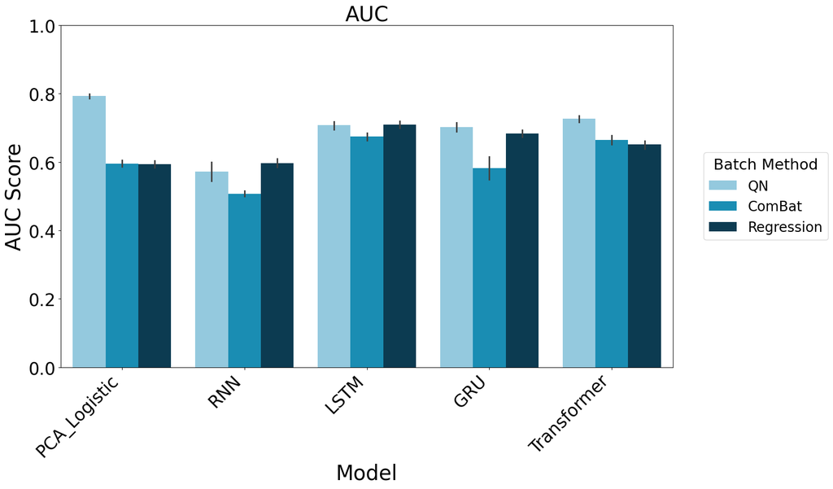

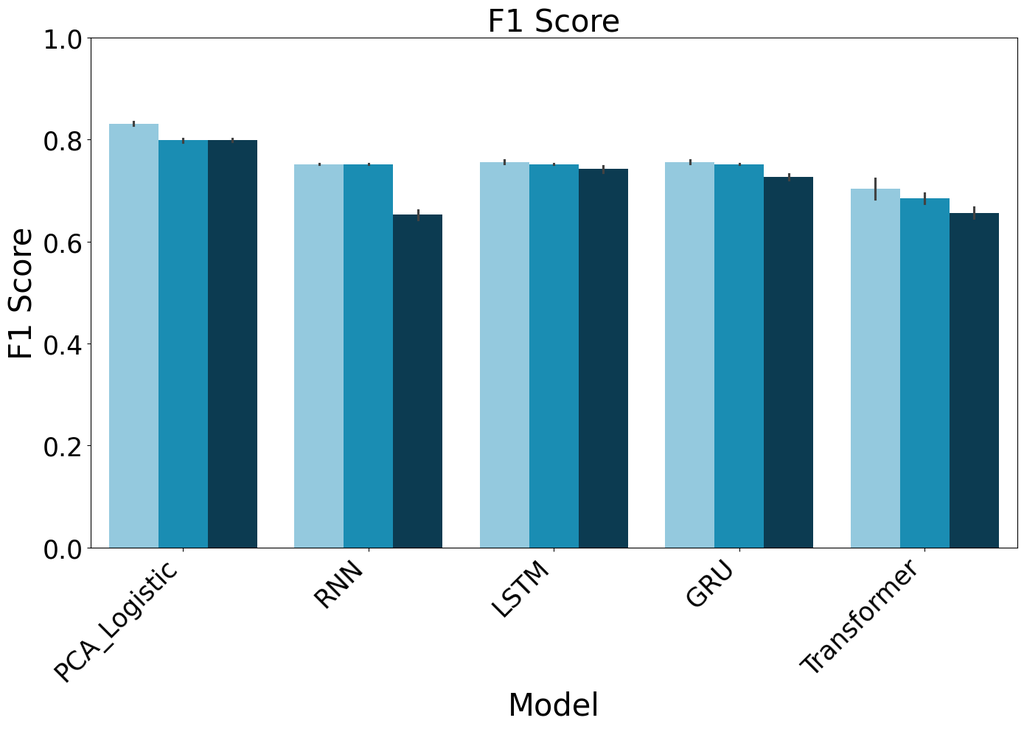

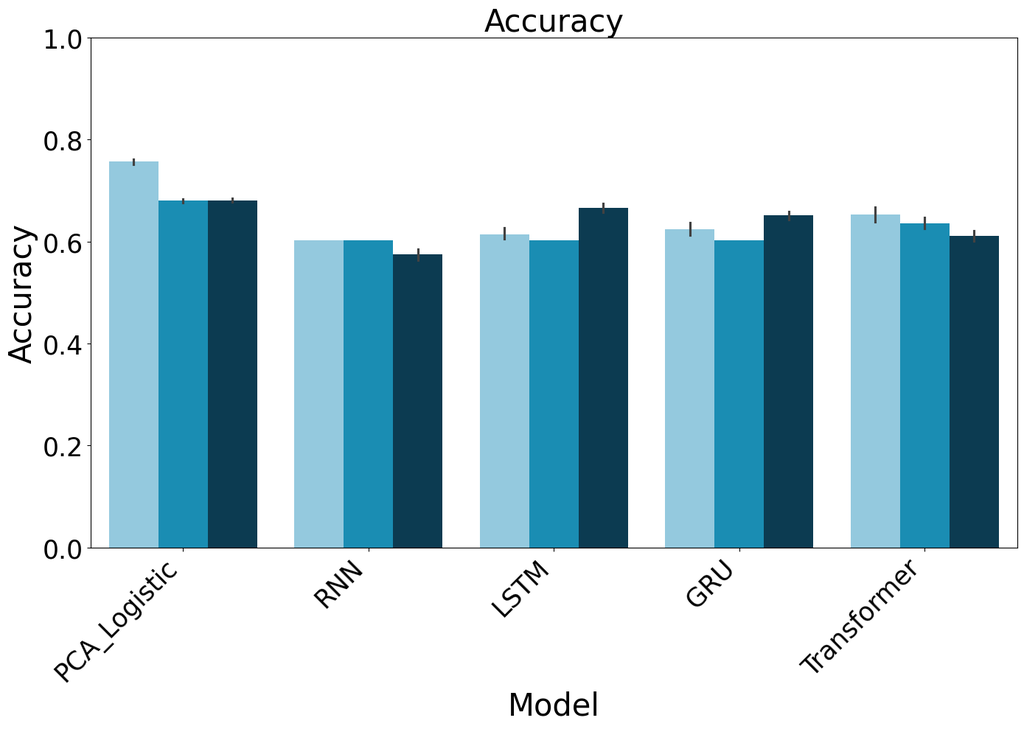

```python
import pandas as pd
import matplotlib.pyplot as plt
import seaborn as sns

# Melt the DataFrame
plot_df = combined_df.melt(
    id_vars=['method', 'model'],
    value_vars=['f1', 'accuracy', 'auc'],
    var_name='Metric',
    value_name='Score'
)

# Set model order (must match 'model' column values exactly)
model_order = ['PCA_Logistic', 'RNN', 'LSTM', 'GRU', 'Transformer']

# Custom color palette
custom_palette = ['#87CEEB', '#009ACD', '#003F5C']

# === AUC Plot (with legend) ===
metric = 'auc'
df_metric = plot_df[plot_df['Metric'] == metric]

plt.figure(figsize=(17, 10))
sns.barplot(
    data=df_metric,
    x='model', y='Score', hue='method',
    ci=95,
    palette=custom_palette,
    order=model_order,
    errorbar='sd'
)

plt.title('AUC', fontsize=30)
plt.xlabel('Model', fontsize=30)
plt.ylabel('AUC Score', fontsize=30)
plt.xticks(rotation=45, ha='right', fontsize=25)
plt.yticks(fontsize=25)
plt.ylim(0, 1)
plt.legend(
    title='Batch Method', title_fontsize=22, fontsize=20,
    loc='center left',
    bbox_to_anchor=(1.05, 0.5),
    borderaxespad=0
)

plt.tight_layout()
plt.savefig("auc_plot.png", dpi=300)
plt.show()

# === F1 and Accuracy Plots (no legend) ===
metrics_to_plot = ['f1', 'accuracy']
titles = {'f1': 'F1 Score', 'accuracy': 'Accuracy'}

for metric in metrics_to_plot:
    df_metric = plot_df[plot_df['Metric'] == metric]

    plt.figure(figsize=(14, 10))
    sns.barplot(
        data=df_metric,
        x='model', y='Score', hue='method',
        ci=95,
        palette=custom_palette,
        order=model_order,
        errorbar='sd'
    )

    plt.title(titles[metric], fontsize=30)
    plt.xlabel('Model', fontsize=30)
    plt.ylabel(f'{titles[metric]}', fontsize=30)
    plt.xticks(rotation=45, ha='right', fontsize=25)
    plt.yticks(fontsize=25)
    plt.ylim(0, 1)
    plt.legend([], [], frameon=False)
    plt.tight_layout()
    plt.savefig(f"{metric}_plot.png", dpi=300)
    plt.show()
```